# Від зв’язку до прогнозу

Моделювання паливної економічності · Auto MPG

Басок Максим · Лабораторна робота №3

## Наскільки точно можна передбачити mpg?

01 / задача

Ми знаємо характеристики авто.  
*Чи можемо передбачити його економічність?*

**398**записів про моделі

**1970–82**історичний період

**Ціль** mpg — милі на галон США**Фактори** маса · потужність · рік · походження

Більше mpg — економніше. Прогноз для нових назв у тому самому періоді, не для сучасних авто. UCI Auto MPG · CC BY 4.0.

## Дві гіпотези до оцінювання

02 / очікування

H1 / МАСА

+1000 lb → −mpg

За однакових потужності, року й походження більша маса пов’язана з нижчим mpg.

H2 / МОДЕЛЬНИЙ РІК

+1 рік → +mpg

Пізніші моделі мають вищий mpg за врахування інших предикторів.

DOE (2023): маса, енерговитрати й технології. EPA (2026): історичні зміни та склад автопарку. Гіпотези підказані EDA ЛР №2 — перевірка розвідувальна.

## Форма зв’язку підказала модифікацію

03 / від EDA до формули

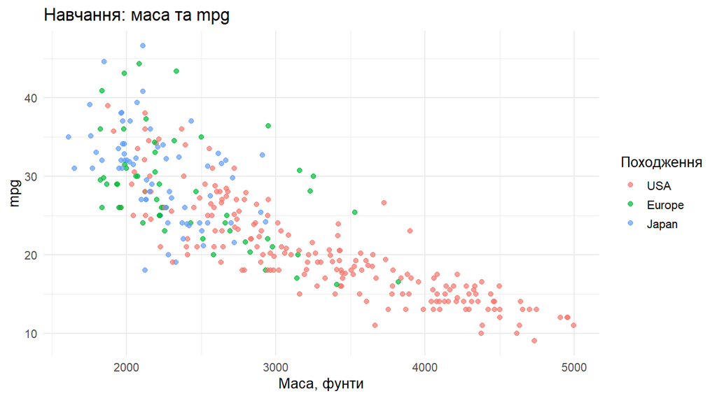

ТІЛЬКИ TRAIN

### Спад є. Пряма описує не все.

Маса входить у M1.

Квадрат маси в M2 має врахувати кривизну.

Графік не доводить причинного впливу маси.

## Назви автомобілів не перетинають поділ

04 / захист від витоку

УСІ ДАНІ**398**записів

→

НАВЧАННЯ**316**244 назви

5 folds × 3 повтори

→

ТЕСТ**82**61 назваПісля фіксації моделі

**Імпутація:** медіана потужності лише з навчальної частини кожного fold.

**Вибір:** найменший середній RMSE. MAE показуємо додатково. Обидві метрики — у mpg.

Seed 312024. Test відкладений від поточного підбору, але весь набір уже переглядався в EDA ЛР №2.

## Квадрат маси зменшив помилку на CV

05 / порівняння моделей

ОБРАНО ЗА CV

M2

**M1:** маса + потужність + рік + походження.

**M2:** ті самі ознаки + квадрат маси.

Обираємо до відкриття тесту. SD між folds: M1 ≈0,25; M2 ≈0,24 mpg. Це не довірчі інтервали.

## Поліпшення є. Залишки не ідеальні.

06 / діагностика

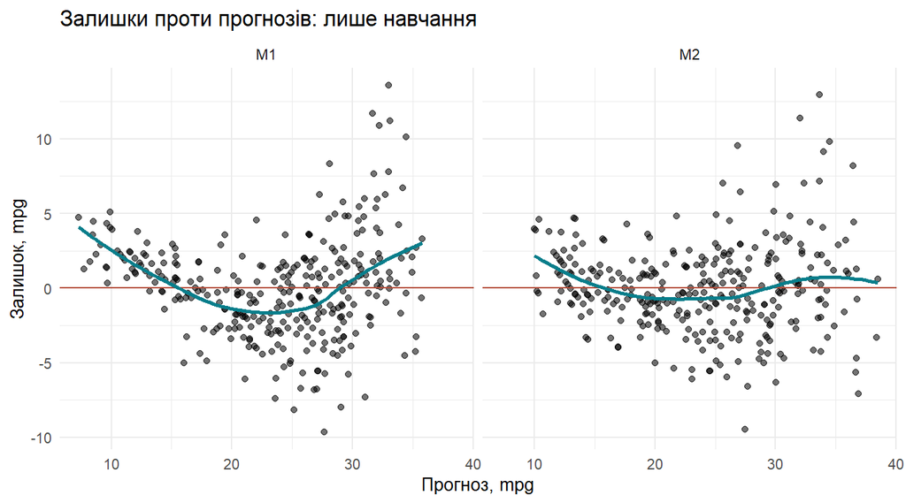

НАВЧАЛЬНІ ДАНІ

### У M2 слабший вигин

Зберігаються неоднаковий розкид і великі залишки.

Перевірено Q–Q, scale–location та Cook. Впливові записи збережено; графіки є у звіті.

## Обидва очікувані напрями підтримуються

07 / гіпотези у базовій M1

H1 · +1000 фунтів

-5,62 mpg

95%: -6,58 … -4,67 mpg

За однакових інших предикторів у M1.

H2 · +1 модельний рік

0,73 mpg

95%: 0,62 … 0,83 mpg

За однакових інших предикторів у M1.

Гіпотези розвідувальні після повного EDA. Якість прогнозу перевіряємо окремо на наступному слайді.

## Тест: прогноз точніший за константу

08 / відкладені 82 записи

[figure not shown]

МОДЕЛЬ M2

2,78

RMSE, mpg

**1,95**MAE, mpg

**8,29**RMSE константи

−66,5% RMSE проти константи

Специфікацію зафіксовано до оцінювання test. Пунктир — ідеальний збіг прогнозу й факту.

## Найбільші помилки — для mpg понад 30

09 / де прогноз слабший

mpg ≤20 · n = 42**2,01**RMSE, mpg

Зміщення: 0,64 mpg

20<mpg≤30 · n = 24**2,50**RMSE, mpg

Зміщення: 0,30 mpg

mpg>30 · n = 16**4,42**RMSE, mpg

Зміщення: -2,45 mpg

У цій підгрупі лише 16 записів. Після огляду помилок модель не змінювалася.

## Модель корисна в межах цих даних

10 / висновок

### Що отримали

M2 точніша за константу.  
Маса й рік мають очікувані умовні зв’язки у M1.

### Що обмежує висновок

Історична вибірка. Попередній EDA всього набору. Неповні характеристики та споріднені моделі.

НАСТУПНИЙ КРОК

Перевірити зафіксовану модель на справді нових даних за тим самим протоколом вимірювання.

Quinlan (1993), Auto MPG, DOI: 10.24432/C5859H · DOE FOTW №1289 (2023) · EPA Automotive Trends 2025 (2026). Повні джерела й обмеження — у звіті.